# IE 582 Project Report

Orkun Irsoy - Sanser Guz

Jan 3rd, 2020

## Introduction

Being a field that is compatible to data mining methods and functional to real life, sports betting is an highly popular field in statistical learning practices. To this day, there are many machine learning, data mining research studies on betting aiming to forecast the match outcomes with accuracy and precision.

In this project we aimed to obtain predicted probabilities for outcomes of English Premier League matches. In this manner, we modeled this problem as a multi-class classification problem and utilized the subjects and methods we were taught during the lecture. The obtained probabilities we set out to define represent the predicted outcomes of matches under three possible cases: Home win, Tie or Away win.

Data we were given contained various features and statistics of matches and teams. In addition to these information, we were also provided with bookmakers’ odds for each match in the state space. Ultimately, we were tasked to best the bookmakers’ odds by providing better results in terms of match outcomes.

Performance metric defined for this project is called RPS (Ranked Probability Score) which yields an accuracy metric for predicted probabilities and their respective observed outcome by taking the ordinal nature of outcomes (Home-Tie-Away) into account. Calculation can be seen in the equation below where r is the number of outcomes, pj is the forecasted probability of outcome j and ej is the actual probability of outcome j.

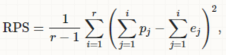

Equation 1: RPS Calculation

## Related Literature

We have conducted a moderate scale literature search on football betting using statistical models. We have found out that there are several classification methods most researchers use in common such as random forest and gradient boosting methods. What these studies differ from each other is their approach to explanatory feature extraction and selection.

ELO ratings are features representing the normalized strength of teams based on the results of their previous matches. Ratings for each team are set to a fixed value at the beginning of the training horizon and updated sequentially with the outcome of each match. Hence, by definition, ELO rating is a cumulative result record of teams that gains meaning as time progresses. Although Hvattum argue that ELO Ratings’ usage in scientific domain of machine learning is limited so far, there still are numerous non-academic studies that utilizes ELO practically. We decided to add several features on ELO in our feature matrix.

Buursma implemented the use of a certain number of historical features (latest n matches) for both teams of a match to predict the outcome probabilities. This method acts as a moving averaged feature generator that takes only the latest information into consideration. We found this approach quite useful as it is very logical to get a grip on and account for the most recent condition of a team. An overall highly successful team might consistently scoring bad in recent games and is expected to do bad for the next.

*Buursma, Douwe. “Predicting sports events from past results Towards effective betting on football matches.” (2011).*

*L. M. Hvattum, and H. Arntzen,Using ELO ratings for match result prediction in association football,International Journal of forecasting26, No. 3 (2010) 460-470.*

## Solution Approaches

### Feature Extraction

Although we are provided odd information for some games, we didn’t use odd data as features since it is usually missing for some of the games we need to predict. Instead, we extracted some features related to last “n” games using the data from matches and stats files. Extracted features can be seen in the table below.

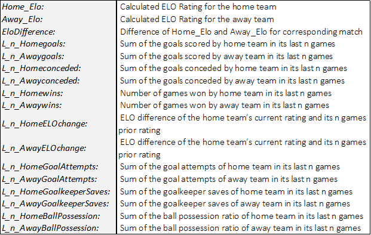

Table 1: Feature Descriptions

### Stochastic Gradient Boosting

Being an advanced tree-based approach, Stochastic Gradient Boosting is quite a suitable method for this task. Parameters to be tuned are number of trees, shrinkage factor and depth. Because of computational complexity, cross validation (10 folds, 2 replications) and parameter tuning took quite some time but we managed to get satisfactory results using this method in RPS performance.

### Decision Trees

Decision trees are widely utilized in the area of data mining. Models created are usually high in descriptive power but it is necessary to tune its parameters to obtain effective results. Therefore we used 10 fold cross validation with 2 replications to determine the values of minimum bucket size and complexity parameters. Different parameter sequences are tried and the best parameter set in terms of RPS is chosen as the final model. Since cross validation is used for parameter tuning, model is tested on a test data apart from the training.

### Random Forest

Another approach we employed was random forest. As in Homework 4, for the number of trees (J) we used 500 and for the minimal number of observations per tree leaf we used 5. For this model we tried to determine the optimum number of feature subset size per each iteration (m). Like the other models 10 fold cv with 2 replications is applied in order to get minimum RPS.

### Lasso Combined With Random Forest

Since using different predictors would decrease the mean RPS we tried some convex combinations of probabilities generated by Lasso model and random forest model as predictors. It turns out that, for some proportion this combination provided best RPS values. Optimum proportion is determined by trying out different combinations for the coefficient p and (1-p)

## Results

Mean of RPS values for each method were recorded and tabulated as follows. We have found that ensemble model of LASSO & Random Forest yielded the lowest RPS values with highest accuracy. LASSO and SGB models also did quite well with a mean RPS around 18%. Best value for historical observation period, n, turned out to be 5.

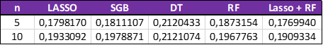

Table 2: Average RPS values of different models for the test data set

LASSO & Random Forest ensemble is selected to be the best model. Using this model, we have obtained predicted probabilities and calculated the RPS values for all 70 matches in 7 rounds (except the one skipped) of the submission schedule.

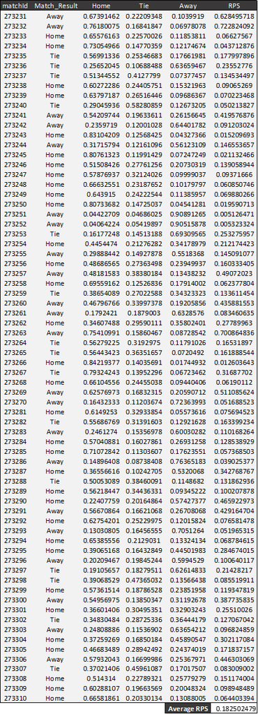

Table 3: RPS values of selected model for 70 matches

## Conclusions and Future Work

In conclusion, this project gave us the opportunity to learn and apply several data mining methods. We have tried five methods namely Lasso Regression, Stochastic Gradient Boosting, Decision Trees, Random Forest and some combination of those models. For each model we tuned parameters using 10 fold cross validation which turns out to be computationally expensive especially for Stochastic Gradient Boosting and Random Forest models. This can be improved by using other functions for SGB such as “xgboost” which provides faster results providing fathoming or parallel run options. During our project we usually kept parameter space narrow in order to get results quicker. thus number of tried parameters can be enlarged to get better insights as a future work.

As for combining models we only tried additive combinations of Lasso and Random Forest Models. Expanding this selection with SGB or applying some other ensemble learning methods such as bagging might be other options to obtain better RPS values for future work.

Although ELO ratings doesn’t provide additional information for the penalized regression model it improved other models. Except from “Ball Possession” other extracted features seem important at least for some of the models. Same methods might be used to work with different features to generalize these results.

## Main Code

Main code and Non-odd feature extraction codes written by us included in this report. R Script files and appendix can be found in [this link](https://github.com/BU-IE-582/fall19-sanserguz/tree/master/ProjectSubmission).

```r
setwd("C:/Users/Orkun/Desktop/IE 582 - Project")

require(TunePareto)
require(glmnet)
require(gbm)
require(rpart)
library(data.table)
library(dplyr)
library(tidyr)
library(randomForest)


source('data_preprocessing.r')
source('non-odd_features.R')
source('ELO_calculations.R')
source('performance_metrics.r')
source('train_models.r')

# Train and test periods are defined beforehand
# trainstartELO refers to the period ELO ratings becomes meaningful

testStart=as.Date('2019-11-01')
testEnd=as.Date('2020-01-03')
trainStart=as.Date('2017-09-16')
trainStartELO=as.Date('2019-01-01')


# Import the necessary data
goaldata<-fread("goals.csv",header=TRUE)
matchdata<-fread("matches.csv",header=TRUE)
betdata<-fread("bets.csv")
bookingdata<-fread("booking.csv")
statdata<-fread("stats.csv")


# Clean the stat data
setnames(statdata,old = "match_id", new = "matchId")
statdata$matchId<-as.character(statdata$matchId)
statdata$home_BallPossession<-gsub("%","",statdata$home_BallPossession)
statdata$away_BallPossession<-gsub("%","",statdata$away_BallPossession)
statdata$home_BallPossession<-as.numeric(statdata$home_BallPossession)/100
statdata$away_BallPossession<-as.numeric(statdata$away_BallPossession)/100


# Convert match data in a suitable format for prepared functions
mraw<-data.table("leagueId"=0,"matchId"=matchdata$match_id,"home"=matchdata$match_hometeam_name,"away"=matchdata$match_awayteam_name,"score"=paste(matchdata$match_hometeam_score,matchdata$match_awayteam_score,sep = ":"),"date"=matchdata$epoch,"type"="soccer")
mraw$leagueId<-as.character(mraw$leagueId)
mraw$matchId<-as.character(mraw$matchId)
mraw$date<-as.numeric(mraw$date)

# Convert bet data in the corresponding format
braw<-data.table("matchId"=betdata$match_id,"betType"= "1x2","oddtype"=betdata$variable,"bookmaker"=betdata$odd_bookmakers,"date"=betdata$odd_epoch,"odd"=betdata$value,"totalhandicap"=NA)
braw[oddtype!="odd_1" & oddtype!="odd_2"& oddtype!="odd_x"]$betType<-"OtherBets"
braw$oddtype<-gsub("_","",braw$oddtype)
braw$oddtype<-gsub("x","X",braw$oddtype)
braw$matchId<-as.character(braw$matchId)
braw$date<-as.numeric(braw$date)
braw$totalhandicap<-as.character(braw$totalhandicap)

# Preprocess matches data
matches=matches_data_preprocessing(mraw)

# Add ELO measures
matches=add_elo(matches,testStart,testEnd)

# Add goals scored and conceded for the home and away team in each ones last N games
matches_L_n=extract_last_ngames(matches,N=10)

# Record the matches info matrix for different n values
matches_L_5=matches_L_n
matches_L_10=matches_L_n
matches_L_15=matches_L_n

# Upon need execute following to compare for different n values
matches_L_n=matches_L_5
matches_L_n=matches_L_10
matches_L_n=matches_L_15


# Divide data based on the provided dates
train_features=matches_L_n[Match_Date>=trainStart & Match_Date<testStart]
test_features=matches_L_n[Match_Date>=testStart]

# Use complete.cases function to clean the data off NA values
# In order to make predictions for future games, refrain from using complete.cases function on test features
train_features<-train_features[complete.cases(train_features)]
test_features<-test_features[complete.cases(test_features)]


## Model 1 - LASSO Regression

# Run glmnet on train data with tuning lambda parameter based on RPS and return predictions based on lambda with minimum RPS
# After few trial we eliminated some of the extracted feature in order to minimize RPS in test data
predictions_glm=train_glmnet(train_features, test_features,not_included_feature_indices=c(1:18,25,26,31,32), alpha=1,nlambda=50, tune_lambda=TRUE,nofReplications=2,nFolds=10,trace=T)

# Calculate mean RPS for test set
mean(RPS_matrix(predictions_glm$predictions[,3:5],res_matrix(predictions_glm$predictions[,2])))

# Obtain the predicted probabilities via matrix form
View(predictions_glm$predictions)
pred<-cbind(predictions_glm$predictions[!is.na(Match_Result)&!is.na(Home)],res_matrix(predictions_glm$predictions[!is.na(Match_Result)&!is.na(Home)],3))
pred<-cbind(pred,RPS=RPS_matrix(pred[,3:5],pred[,6:8]))



#Before proceeding forward use train data from the trainStartELO to use reasonable ELO Ratings as features
train_features=matches_L_n[Match_Date>=trainStartELO & Match_Date<testStart]
test_features=matches_L_n[Match_Date>=testStart]
train_features<-train_features[complete.cases(train_features)]
test_features<-test_features[complete.cases(test_features)]


## Model 2 - Stochastic Gradient Boosting

noftrees=500
sampling_fraction=0.5
depth= c(1,3,5)
learning_rate= c(0.1,0.01,0.001)

#GBMperf=matrix(0,ncol=3,nrow=3)

# Create dataframe to store results of each combination
sgb_RPS=data.frame(matrix(NA,nrow=3*3,ncol=3))

Folds=10
Replication = 2
cvindices=generateCVRuns(train_features$Match_Result,nfold = Folds, ntimes = Replication, stratified = TRUE)
a=1


for(i in 1:length(depth)){

  for(j in 1:length(learning_rate)){
    sumRPS=0

    for(k in 1:Replication){
      indices=cvindices[[k]]

      for(l in 1:Folds){

        test=order(indices[[l]])
        cvtrain=train_features[-test,]
        cvtest=train_features[test,]

              boosting_model=gbm(as.factor(cvtrain$Match_Result)~., data=cvtrain[,c(19:24,27:30)],distribution = "multinomial", n.trees = noftrees,
                       interaction.depth = depth[i], n.minobsinnode = 5, shrinkage =learning_rate[j] ,
                       bag.fraction = sampling_fraction, cv.folds = 5)
              bestno = gbm.perf(boosting_model,method = "cv")
              sgb_pred=cbind(cvtest[,c(2,10)],predict(boosting_model,cvtest,n.trees = bestno ,type="response")[,1:3,1])
              sgb_pred<- sgb_pred[,c(1,2,4,5,3)]
              sumRPS<- sumRPS + mean(rps_calc(sgb_pred,3))

      }
    }
    sgb_RPS[a,]<- c(j,i,sumRPS/20)
    a=a+1

  }
}

# Get the parameters giving minimum RPS
index=which.min(sgb_RPS$X3)
opt_learning_rate=learning_rate[sgb_RPS[index,1]]
opt_depth=depth[sgb_RPS[index,2]]



# Obtain final model and calculate RPS for SGB model
final_sgb= gbm(as.factor(train_features$Match_Result)~., data=train_features[,c(19:24,27:30)],distribution = "multinomial", n.trees = noftrees,
               interaction.depth = opt_depth, n.minobsinnode = 5, shrinkage =opt_learning_rate ,
               bag.fraction = sampling_fraction, cv.folds = 5)
bestno = gbm.perf(boosting_model,method = "cv")
final_sgb_pred=cbind(test_features[,c(2,10)],predict(final_sgb,test_features,n.trees = bestno ,type="response")[,1:3,1])
final_sgb_pred<- final_sgb_pred[,c(1,2,4,5,3)]
mean(rps_calc(final_sgb_pred,3))





## Model 3 - Decision Tree

# 10 fold cross validation is conducted to tune minbucket and complexity parameters

# Create dataframe to store results of each combination
dt_RPS=data.frame(matrix(NA,nrow=9*15,ncol=3))
colnames(dt_RPS)=c("MinBucket","Cp","RPS")

# CV indices were obtained using generateCVRuns function
Folds=10
Replication = 2
cvindices=generateCVRuns(train_features$Match_Result,nfold = Folds, ntimes = Replication, stratified = TRUE)
a=1

# For each parameter combination calculate the mean RPS and write on dt_RPS
for(i in seq(0.001,0.015,by=0.001)) {
  for(j in seq(20,60,by=5)){
    sumRPS=0
    for(k in 1:Replication){
      indices=cvindices[[k]]
      for(l in 1:Folds){
        test=order(indices[[l]])
        cvtrain=train_features[-test,]
        cvtest=train_features[test,]
        tree=rpart(Match_Result~.,cvtrain[,c(10,16:32)],method="class",
                   control=rpart.control(minbucket=j,cp=i))
        dtpred=predict(tree, cvtest[,c(10,16:32)], type = 'prob')
        dtpred<- cbind(cvtest[,c(2,10)],dtpred)
        dtpred<- dtpred[,c(1,2,4,5,3)]
        sumRPS<- sumRPS + mean(rps_calc(dtpred,3))

      }
    }
    dt_RPS[a,]<- c(j,i,sumRPS/20)
    a=a+1
  }
}

# Get the parameters giving minimum RPS
index=which.min(dt_RPS$RPS)
optbucket=dt_RPS[index,1]
optcp=dt_RPS[index,2]


# Obtain final model and calculate RPS for Decision Tree model
final_dt= rpart(Match_Result~.,train_features[,c(10,16:32)],method="class",
                    control=rpart.control(minbucket=optbucket,cp=optcp))
final_dtpred=predict(final_dt, test_features[,c(10,16:32)], type = 'prob')
final_dt<- cbind(test_features[,c(2,10)],final_dtpred)
final_dt<- final_dt[,c(1,2,4,5,3)]
final_dt_RPS<- rps_calc(final_dt,3)
mean(final_dt_RPS)

str(final_dt)
fancyRpartPlot(final_dt)
barplot(final_dt$variable.importance)
final_dt$variable.importance

## Model 4 - Random Forest

# Number of trees, number of folds and replications are predefined.
NoOfTrees=500
Folds=10
Replication = 2

# Generate sequence of number of sampled features for each tree
Mrange = 1:17

# Create matrix to store RPS values of each m value
rf_RPSmean=matrix(NA,nrow=17,ncol=20)

# CV indices were obtained using generateCVRuns function
cvindices=generateCVRuns(train_features$Match_Result,nfold = Folds, ntimes = Replication, stratified = TRUE)
k=1

# 10 fold cross validation is conducted to tune m

for(i in 1:Replication) {
  indices=cvindices[[i]]
  for(j in 1:Folds){
    test=order(indices[[j]])
    cvtrain=train_features[-test,]
    cvtest=train_features[test,]
      for(m in Mrange)
      {
        rffit = randomForest(formula = as.factor(Match_Result) ~.,data=cvtrain[,c(10,16:32)], ntrees=NoOfTrees, mtry=m)
        rfpred=predict(rffit, cvtest[,c(16:32)], type = 'prob')
        rfpred<- cbind(cvtest[,c(2,10)],rfpred)
        rfpred<- rfpred[,c(1,2,4,5,3)]
        rf_RPS<- rps_calc(rfpred,3)
        rf_RPSmean[m,k]=mean(rf_RPS)

      }
    k=k+1
  }
}


# Get optimal number of subsets and obtain the final model
best_m=match(min(rowMeans(rf_RPSmean)),rowMeans(rf_RPSmean))
final_rf= randomForest(formula = as.factor(Match_Result) ~.,data=train_features[,c(10,19:30)], ntrees=NoOfTrees, mtry=7)

# Calculate RPS for Random Forest Model
final_rfpred=predict(final_rf, test_features[,c(19:30)], type = 'prob')
final_rfpred<- cbind(test_features[,c(2,10)],final_rfpred)
final_rfpred<- final_rfpred[,c(1,2,4,5,3)]
final_rf_RPS<- rps_calc(final_rfpred,3)
mean(final_rf_RPS)




## Model 5 - Combined glm and rf

# Try different proportions of the models and choose the one with minimum RPS
p_seq<-seq(0,1,by=0.1)
combined_RPS<-c()

for (p in 1:length(p_seq)) {

  combined_prob=(p_seq[p])*final_rfpred[,3:5]+(1 - p_seq[p])*pred[,3:5]
  combined<-data.frame(matchId=final_rfpred$matchId,Match_Result=final_rfpred$Match_Result)
  combined<-cbind(combined,combined_prob)
  combined_RPS[p]<-mean(rps_calc(combined,3))
}

combined_RPS
optimum_p<-p_seq[which.min(combined_RPS)]
optimum_p
final_combined_RPS<-combined_RPS[which.min(combined_RPS)]
final_combined_RPS


# Following iteration carries out the task of testing the final model for certain matches
# Probabilities are predicted and RPS is calculated for matches of submission schedule

combined_prob=(optimum_p)*final_rfpred[,3:5]+(1 -optimum_p)*pred[,3:5]
combined<-cbind(test_features[,c(2,10)],combined_prob)
combined<-cbind(combined,RPS=rps_calc(combined,3))
mean(rps_calc(combined,3))
ProjectRounds=combined[(as.numeric(matchId)>273230 & as.numeric(matchId)<273271) | (as.numeric(matchId)>273280 & as.numeric(matchId)<273311)]
mean(ProjectRounds$RPS)
```

## Non-Odd Feature Extraction

```r
#Function intents to extract related features of a specific team using its last n match and stat data
extract_last_ngames <- function(matches,N=10){


  #Create dataframe to store extracted features
  L_n_matches<-cbind(matches,L_n_Homegoals= as.numeric(NA),L_n_Awaygoals=as.numeric(NA),L_n_Homeconceded= as.numeric(NA),
                     L_n_Awayconceded=as.numeric(NA),L_n_Homewins= as.numeric(NA),L_n_Awaywins=as.numeric(NA),
                     L_n_HomeELOchange= as.numeric(NA),L_n_AwayELOchange=as.numeric(NA),L_n_HomeGoalAttempts= as.numeric(NA),
                     L_n_AwayGoalAttempts= as.numeric(NA),L_n_HomeGoalkeeperSaves= as.numeric(NA),
                     L_n_AwayGoalkeepersaves= as.numeric(NA),L_n_HomeBallPossession= as.numeric(NA),
                     L_n_AwayBallPossession= as.numeric(NA))

  # Home Team
  for (i in 1:length(L_n_matches$matchId)) {

      # Get home teams name and corresponding date
      h<- L_n_matches$Home[i]
      matchdate<- L_n_matches$Match_Date[i]

      # Create last n games data
      x<-matches[(Home==h|Away==h)& Match_Date<matchdate ]
      x<-x[!is.na(Match_Result)]
      x<-x[order(Match_Date)]

      # If team doesn't have last n data for the corresponding date skip the procedure (leave NA)
      if (length(x$matchId) < N) {next}

      # Obtain last n game wins,goals scored and conceded
      y<-tail(x,N)
      L_n_matches[i,]$L_n_Homegoals<-sum(as.numeric(y$Home==h)*y$Home_Score + as.numeric(y$Away==h)*y$Away_Score)
      L_n_matches[i,]$L_n_Homeconceded<-sum(as.numeric(y$Home==h)*y$Away_Score + as.numeric(y$Away==h)*y$Home_Score)
      L_n_matches[i,]$L_n_Homewins<-sum(as.numeric(y$Home==h)*y$Result_Home + as.numeric(y$Away==h)*y$Result_Away)

      # Obtain ELO difference between the first and nth game
      ELO1<-as.numeric(y[1,]$Home==h)*y[1,]$Home_Elo + as.numeric(y[1,]$Away==h)*y[1,]$Away_Elo
      ELON<-as.numeric(y[N,]$Home==h)*y[N,]$Home_Elo + as.numeric(y[N,]$Away==h)*y[N,]$Away_Elo
      L_n_matches[i,]$L_n_HomeELOchange<-ELON-ELO1

      # For stat data merge dataframes to obtain last n games' statitstics
      z<-merge(x,statdata[,list(matchId,home_GoalAttempts,away_GoalAttempts,home_GoalkeeperSaves,away_GoalkeeperSaves,home_BallPossession,away_BallPossession)], by = "matchId")
      z=z[complete.cases(z)==TRUE]

      # If team doesn't have last n data for the corresponding date skip the procedure (leave NA)
      if (length(z$matchId) < N) {next}
      z<-tail(z,N)

      # Obtain last n game goal attempts, goalkeeper saves and ball possession
      L_n_matches[i,]$L_n_HomeGoalAttempts<-sum(as.numeric(z$Home==h)*z$home_GoalAttempts+as.numeric(z$Away==h)*z$away_GoalAttempts)
      L_n_matches[i,]$L_n_HomeGoalkeeperSaves<-sum(as.numeric(z$Home==h)*z$home_GoalkeeperSaves+as.numeric(z$Away==h)*z$away_GoalkeeperSaves)
      L_n_matches[i,]$L_n_HomeBallPossession<-sum(as.numeric(z$Home==h)*z$home_BallPossession+as.numeric(z$Away==h)*z$away_BallPossession)

  }

  # Away Team
  for (i in 1:length(L_n_matches$matchId)) {

    # Get away teams name and corresponding date
    a<- L_n_matches$Away[i]
    matchdate<- L_n_matches$Match_Date[i]

    # Create last n games data
    x<-matches[(Home==a|Away==a)& Match_Date<=matchdate ]
      x<-x[!is.na(Match_Result)]
      x<-x[order(Match_Date)]

      # If team doesn't have last n data for the corresponding date skip the procedure (leave NA)
      if (length(x$matchId) < N){next}

      # Obtain last n game wins,goals scored and conceded
      y<-tail(x,N)
      L_n_matches[i,]$L_n_Awaygoals<-sum(as.numeric(y$Home==a)*y$Home_Score + as.numeric(y$Away==a)*y$Away_Score)
      L_n_matches[i,]$L_n_Awayconceded<-sum(as.numeric(y$Home==a)*y$Away_Score + as.numeric(y$Away==a)*y$Home_Score)
      L_n_matches[i,]$L_n_Awaywins<-sum(as.numeric(y$Home==a)*y$Result_Home + as.numeric(y$Away==a)*y$Result_Away)

      # Obtain ELO difference between the first and nth game
      ELO1<-as.numeric(y[1,]$Home==a)*y[1,]$Home_Elo + as.numeric(y[1,]$Away==a)*y[1,]$Away_Elo
      ELON<-as.numeric(y[N,]$Home==a)*y[N,]$Home_Elo + as.numeric(y[N,]$Away==a)*y[N,]$Away_Elo
      L_n_matches[i,]$L_n_AwayELOchange<-ELON-ELO1


      # For stat data merge dataframes to obtain last n games' statitstics
      z<-merge(x,statdata[,list(matchId,home_GoalAttempts,away_GoalAttempts,home_GoalkeeperSaves,away_GoalkeeperSaves,home_BallPossession,away_BallPossession)], by = "matchId")
      z=z[complete.cases(z)==TRUE]

      # If team doesn't have last n data for the corresponding date skip the procedure (leave NA)
      if (length(z$matchId) < N) {next}
      z<-tail(z,N)

      # Obtain last n game goal attempts, goalkeeper saves and ball possession
      L_n_matches[i,]$L_n_AwayGoalAttempts<-sum(as.numeric(z$Home==a)*z$home_GoalAttempts+as.numeric(z$Away==a)*z$away_GoalAttempts)
      L_n_matches[i,]$L_n_AwayGoalkeepersaves<-sum(as.numeric(z$Home==a)*z$home_GoalkeeperSaves+as.numeric(z$Away==a)*z$away_GoalkeeperSaves)
      L_n_matches[i,]$L_n_AwayBallPossession<-sum(as.numeric(z$Home==a)*z$home_BallPossession+as.numeric(z$Away==a)*z$away_BallPossession)

  }
  return(L_n_matches)
}
```